# 2026 WNBA Postseason Predictions & Regular-Season Model Accuracy Review

## Part 2: 2026 WNBA Postseason Predictions

### Confirmed bracket and format

The 2026 postseason format and first-round matchups were verified via live web search (not assumed to carry over from a prior season) against [Yahoo Sports](https://sports.yahoo.com/wnba/breaking-news/article/wnba-playoffs-2026-matchups-bracket-full-schedule-and-how-to-watch-141426723.html), [CBS Sports](https://www.cbssports.com/wnba/news/2026-wnba-playoffs-bracket-schedule/), and [NBC Sports](https://www.nbcsports.com/wnba/news/2026-wnba-playoffs-scenarios-seeding-tiebreakers-updated-bracket-and-standings):

- **First Round (Bo3, 1-1-1):** No reseeding — the fixed bracket is #1 vs #8, #2 vs #7, #3 vs #6, #4 vs #5. Higher seed hosts Games 1 and 3; the lower seed hosts Game 2.
- **Semifinals (Bo5, 2-2-1):** Higher seed hosts Games 1, 2, and 5 if necessary.
- **Finals (Bo7, 2-2-1-1-1):** Higher seed hosts Games 1, 2, 5, and 7.

Confirmed 2026 seeds and first-round matchups: **(1) Minnesota Lynx** vs (8) New York Liberty, **(2) Golden State Valkyries** vs (7) Dallas Wings, **(3) Las Vegas Aces** vs (6) Indiana Fever, **(4) Atlanta Dream** vs (5) Washington Mystics. This matches `playoff_simulator.R`’s already-coded `PLAYOFF_FORMATS` registry (bo3/bo5/bo7 home-flag sequences + win thresholds) exactly — no format changes were needed there.

### Team inputs: real empirical net ratings

Because the regular season has actually been played, this section uses each playoff team’s real per-game point differential from `data/box_scores_cache.rds` as the base net rating — not `cache/projected_wnba_standings.rds`, which is a forward-looking model projection meant for mid-season use. `playoff_simulator.R`’s `get_playoff_adjusted_rating()` then applies its real-RAPM playoff-leverage adjustment (`cache/rapm_ratings.rds`, which now exists and has real per-team RAPM data for all 8 of these teams, so the fallback contender-leverage table is not used here).

```r
suppressMessages(source("playoff_simulator.R"))  # also re-runs its own bo3/bo5/bo7 demo suite once (harmless)

b26 <- box |> filter(season == 2026)
net_real <- b26 |>
  group_by(team_abbreviation) |>
  summarise(GP = n(), net_rating = mean(team_score - opponent_team_score), .groups = "drop")

seeds <- tibble(
  seed = 1:8,
  abbr = c("MIN", "GS", "LV", "ATL", "WSH", "IND", "DAL", "NY")
) |>
  mutate(team = unname(WNBA_TEAMS[abbr])) |>
  left_join(net_real, by = c("abbr" = "team_abbreviation")) |>
  rowwise() |>
  mutate(net_adj = get_playoff_adjusted_rating(team, net_rating)) |>
  ungroup()

knitr::kable(seeds |> select(seed, team, GP, net_rating, net_adj), digits = 2,
             caption = "2026 playoff field: real regular-season per-game net rating and RAPM-adjusted playoff rating.")
```

2026 playoff field: real regular-season per-game net rating and RAPM-adjusted playoff rating.

| seed | team | GP | net_rating | net_adj |
| --- | --- | --- | --- | --- |
| 1 | Minnesota Lynx | 46 | 6.17 | 7.86 |
| 2 | Golden State Valkyries | 47 | 7.02 | 8.46 |
| 3 | Las Vegas Aces | 48 | 5.40 | 7.49 |
| 4 | Atlanta Dream | 46 | 7.28 | 8.96 |
| 5 | Washington Mystics | 46 | 0.50 | 2.29 |
| 6 | Indiana Fever | 47 | 4.79 | 6.23 |
| 7 | Dallas Wings | 47 | 3.45 | 5.25 |
| 8 | New York Liberty | 47 | 3.81 | 5.36 |

### Bracket win-probability tree

Rather than a single flat Monte Carlo bracket draw, each round’s series is simulated directly via `simulate_single_series()` for every matchup that fixed-bracket structure (no reseeding, confirmed above) makes possible, and probabilities are combined analytically across rounds — e.g. Minnesota’s probability of reaching the Final is `P(MIN wins Round 1)` times the probability-weighted sum, over Atlanta and Washington (Minnesota’s only two possible semifinal opponents), of Minnesota winning that specific semifinal series. This avoids simulation noise from re-drawing the whole bracket tens of thousands of times and makes every intermediate number auditable.

```r
team_of <- function(s) seeds$team[seeds$seed == s]
adj_of  <- function(s) seeds$net_adj[seeds$seed == s]

series_prob_high <- function(seed_high, seed_low, format) {
  simulate_single_series(
    team_high = team_of(seed_high), team_low = team_of(seed_low),
    net_high = adj_of(seed_high), net_low = adj_of(seed_low),
    n_sims = 10000, format = format
  )$p_high_seed_win
}
```

#### Round 1 (Best-of-3)

```r
r1_pairs <- list(c(1, 8), c(2, 7), c(3, 6), c(4, 5))
r1 <- tibble(
  seed_high = sapply(r1_pairs, `[`, 1),
  seed_low  = sapply(r1_pairs, `[`, 2)
) |>
  mutate(
    team_high = sapply(seed_high, team_of),
    team_low  = sapply(seed_low, team_of),
    p_high    = mapply(series_prob_high, seed_high, seed_low, format = "bo3")
  )

knitr::kable(r1 |> select(team_high, team_low, p_high), digits = 3,
             caption = "Round 1 (Best-of-3), pre-series model prediction: probability the higher seed wins the series.")
```

Round 1 (Best-of-3), pre-series model prediction: probability the higher seed wins the series.

| team_high | team_low | p_high |
| --- | --- | --- |
| Minnesota Lynx | New York Liberty | 0.625 |
| Golden State Valkyries | Dallas Wings | 0.670 |
| Las Vegas Aces | Indiana Fever | 0.589 |
| Atlanta Dream | Washington Mystics | 0.788 |

#### Round 1 — actual results (updated 2026-10-03, now complete)

Round 1 has fully played out since the pre-series prediction above was made. Per an independent check of `data/box_scores_cache.rds` (re-ingested live via `daily_ingest.R` as part of this update, max date now 2026-10-02), **all four series are decided**: the two Game 3s that were still pending as of the prior update (LV vs IND 2026-10-01, GS vs DAL 2026-10-02) have since been played and ingested.

```r
r1_actual <- tibble::tribble(
  ~seed_high, ~seed_low, ~status,     ~high_wins, ~low_wins,
  1,          8,         "DECIDED",   0,          2,
  2,          7,         "DECIDED",   2,          1,
  3,          6,         "DECIDED",   2,          1,
  4,          5,         "DECIDED",   2,          0
)

r1_actual <- r1_actual |>
  mutate(
    team_high = sapply(seed_high, team_of),
    team_low  = sapply(seed_low, team_of),
    p_high_advances = as.numeric(high_wins == 2)
  )

knitr::kable(
  r1_actual |> select(team_high, team_low, status, high_wins, low_wins, p_high_advances),
  digits = 3,
  caption = "Round 1 final results (all four series decided). p_high_advances is 1 if the higher seed won the series, 0 otherwise."
)
```

Round 1 final results (all four series decided). p_high_advances is 1 if the higher seed won the series, 0 otherwise.

| team_high | team_low | status | high_wins | low_wins | p_high_advances |
| --- | --- | --- | --- | --- | --- |
| Minnesota Lynx | New York Liberty | DECIDED | 0 | 2 | 0 |
| Golden State Valkyries | Dallas Wings | DECIDED | 2 | 1 | 1 |
| Las Vegas Aces | Indiana Fever | DECIDED | 2 | 1 | 1 |
| Atlanta Dream | Washington Mystics | DECIDED | 2 | 0 | 1 |

```r
cat(sprintf(
  "Headline: #8 New York Liberty swept #1 Minnesota Lynx 2-0 — the model's #1 championship favorite (23.9%%, Conclusion of the original pre-series render) is already eliminated. #4 Atlanta Dream swept #5 Washington Mystics 2-0. #2 Golden State Valkyries beat #7 Dallas Wings 2-1 (won a decisive Game 3 the model had at 65.3%% pre-game). #3 Las Vegas Aces beat #6 Indiana Fever 2-1 (won a decisive Game 3 the model had at 59.0%% pre-game). Both confirmed semifinals: (4) Atlanta vs (8) New York, and (2) Golden State vs (3) Las Vegas.\n"
))
```

[output not shown]

```r
# Downstream rounds use this fully-resolved adv_prob, not the pre-series model-only version above.
adv_prob <- setNames(rep(NA_real_, 8), 1:8)
for (i in seq_len(nrow(r1_actual))) {
  adv_prob[as.character(r1_actual$seed_high[i])] <- r1_actual$p_high_advances[i]
  adv_prob[as.character(r1_actual$seed_low[i])]  <- 1 - r1_actual$p_high_advances[i]
}
```

#### Round 2 (Best-of-5 Semifinals)

The bracket is fixed, so each semifinal’s slot was always known: the winner of (1 vs 8) meets the winner of (4 vs 5); the winner of (2 vs 7) meets the winner of (3 vs 6). With Round 1 now fully decided, both semifinal *matchups* are confirmed too: **(4) Atlanta Dream vs (8) New York Liberty**, and **(2) Golden State Valkyries vs (3) Las Vegas Aces**. The table below still shows the general pairing-probability computation (unchanged code from the pre-series version of this report), but with `adv_prob` now 0/1 for every seed, each half collapses to its one real pairing with probability 1 — the other three hypothetical pairings per half now show `pairing_prob` of 0.

```r
half_pairs <- list(top = list(c(1, 8), c(4, 5)), bottom = list(c(2, 7), c(3, 6)))

semi_finalist_prob <- setNames(rep(0, 8), 1:8)
semi_detail <- list()

for (half_name in names(half_pairs)) {
  g1 <- half_pairs[[half_name]][[1]]; g2 <- half_pairs[[half_name]][[2]]
  for (a in g1) for (b in g2) {
    pairing_prob <- adv_prob[as.character(a)] * adv_prob[as.character(b)]
    seed_high <- min(a, b); seed_low <- max(a, b)
    p_high <- series_prob_high(seed_high, seed_low, format = "bo5")
    p_a_win <- if (a == seed_high) p_high else (1 - p_high)
    semi_finalist_prob[as.character(a)] <- semi_finalist_prob[as.character(a)] + pairing_prob * p_a_win
    semi_finalist_prob[as.character(b)] <- semi_finalist_prob[as.character(b)] + pairing_prob * (1 - p_a_win)
    semi_detail[[length(semi_detail) + 1]] <- tibble(
      half = half_name, team_a = team_of(a), team_b = team_of(b),
      pairing_prob = pairing_prob, p_a_win = p_a_win
    )
  }
}

knitr::kable(bind_rows(semi_detail), digits = 3,
             caption = "Round 2 (Best-of-5): every possible semifinal pairing given Round 1, its probability of occurring, and the probability the first-listed team wins it.")
```

Round 2 (Best-of-5): every possible semifinal pairing given Round 1, its probability of occurring, and the probability the first-listed team wins it.

| half | team_a | team_b | pairing_prob | p_a_win |
| --- | --- | --- | --- | --- |
| top | Minnesota Lynx | Atlanta Dream | 0 | 0.473 |
| top | Minnesota Lynx | Washington Mystics | 0 | 0.789 |
| top | New York Liberty | Atlanta Dream | 1 | 0.301 |
| top | New York Liberty | Washington Mystics | 0 | 0.626 |
| bottom | Golden State Valkyries | Las Vegas Aces | 1 | 0.577 |
| bottom | Golden State Valkyries | Indiana Fever | 0 | 0.640 |
| bottom | Dallas Wings | Las Vegas Aces | 0 | 0.363 |
| bottom | Dallas Wings | Indiana Fever | 0 | 0.426 |

#### Round 3 (Best-of-7 Finals) and championship probabilities

```r
top_candidates <- c(1, 4, 5, 8); bottom_candidates <- c(2, 3, 6, 7)
champ_prob <- setNames(rep(0, 8), 1:8)
finals_detail <- list()

for (a in top_candidates) for (b in bottom_candidates) {
  pairing_prob <- semi_finalist_prob[as.character(a)] * semi_finalist_prob[as.character(b)]
  if (pairing_prob < 1e-9) next
  seed_high <- min(a, b); seed_low <- max(a, b)
  p_high <- series_prob_high(seed_high, seed_low, format = "bo7")
  p_a_win <- if (a == seed_high) p_high else (1 - p_high)
  champ_prob[as.character(a)] <- champ_prob[as.character(a)] + pairing_prob * p_a_win
  champ_prob[as.character(b)] <- champ_prob[as.character(b)] + pairing_prob * (1 - p_a_win)
  finals_detail[[length(finals_detail) + 1]] <- tibble(
    team_top = team_of(a), team_bottom = team_of(b), pairing_prob = pairing_prob, p_top_win = p_a_win
  )
}

knitr::kable(bind_rows(finals_detail) |> arrange(desc(pairing_prob)), digits = 3,
             caption = "Every possible Finals pairing, its probability of occurring, and the probability the first-listed team wins it (only pairings with non-negligible probability shown).")
```

Every possible Finals pairing, its probability of occurring, and the probability the first-listed team wins it (only pairings with non-negligible probability shown).

| team_top | team_bottom | pairing_prob | p_top_win |
| --- | --- | --- | --- |
| Atlanta Dream | Golden State Valkyries | 0.403 | 0.514 |
| Atlanta Dream | Las Vegas Aces | 0.295 | 0.568 |
| New York Liberty | Golden State Valkyries | 0.174 | 0.295 |
| New York Liberty | Las Vegas Aces | 0.127 | 0.350 |

```r
final_table <- seeds |>
  mutate(
    p_reach_semis  = adv_prob[as.character(seed)],
    p_reach_finals = semi_finalist_prob[as.character(seed)],
    p_champion     = champ_prob[as.character(seed)]
  ) |>
  arrange(desc(p_champion)) |>
  select(seed, team, p_reach_semis, p_reach_finals, p_champion)

knitr::kable(final_table, digits = 3,
             caption = sprintf("2026 WNBA championship probabilities by seed (columns sum to 1: %.3f).", sum(champ_prob)))
```

| seed | team | p_reach_semis | p_reach_finals | p_champion |
| --- | --- | --- | --- | --- |
| 4 | Atlanta Dream | 1 | 0.699 | 0.375 |
| 2 | Golden State Valkyries | 1 | 0.577 | 0.319 |
| 3 | Las Vegas Aces | 1 | 0.423 | 0.211 |
| 8 | New York Liberty | 1 | 0.301 | 0.096 |
| 1 | Minnesota Lynx | 0 | 0.000 | 0.000 |
| 5 | Washington Mystics | 0 | 0.000 | 0.000 |
| 6 | Indiana Fever | 0 | 0.000 | 0.000 |
| 7 | Dallas Wings | 0 | 0.000 | 0.000 |

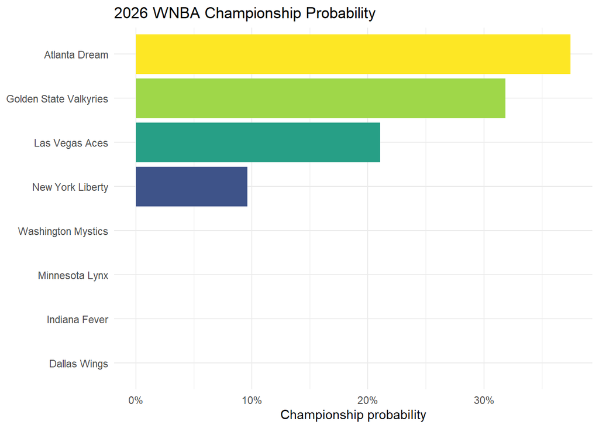

2026 WNBA championship probability by team, from the bracket win-probability tree.

```r
final_table |>
  mutate(team = fct_reorder(team, p_champion)) |>
  ggplot(aes(x = p_champion, y = team, fill = p_champion)) +
  geom_col() +
  scale_fill_viridis_c(guide = "none") +
  scale_x_continuous(labels = scales::percent) +
  theme_minimal() +
  labs(title = "2026 WNBA Championship Probability", x = "Championship probability", y = NULL)
```

### Cross-check against the live pipeline’s own Game 1 predictions

`prediction_accuracy_logger.R`’s `log_todays_predictions()` logged real, `LIVE_ODDS_API`-sourced pre-game predictions for all four 2026-09-27 Game 1s. Those rows are now `status == "RESOLVED"` (the games have since been played) rather than `PENDING` as they were when this report was first drafted — the filter below was updated accordingly, otherwise it would have silently returned zero rows. These predictions come from the live pipeline’s own market-odds-blended win model, an independent input from this section’s box-score-only, RAPM-adjusted series simulator — comparing them against each other, and now against the real outcome, is a useful sanity check, not a guarantee of agreement.

```r
game1_preds <- log |>
  filter(!is_synthetic, status == "RESOLVED", as.Date(game_date) == as.Date("2026-09-27"),
         home_team %in% seeds$abbr) |>
  select(game_date, home_team, away_team, predicted_home_win_prob, predicted_winner)

game1_bracket <- r1 |>
  mutate(
    home_abbr = seeds$abbr[match(team_high, seeds$team)],
    away_abbr = seeds$abbr[match(team_low, seeds$team)],
    bracket_p_home_win = p_high  # team_high is the series host / higher seed in every Round 1 pairing
  ) |>
  select(home_abbr, away_abbr, bracket_p_home_win)

game1_actual <- box |>
  filter(game_date == as.Date("2026-09-27"), team_home_away == "home") |>
  mutate(actual_home_win = team_winner) |>
  select(home_abbr = team_abbreviation, actual_home_win)

comparison <- game1_preds |>
  left_join(game1_bracket, by = c("home_team" = "home_abbr", "away_team" = "away_abbr")) |>
  left_join(game1_actual, by = c("home_team" = "home_abbr")) |>
  select(game_date, home_team, away_team, live_pipeline_p_home_win = predicted_home_win_prob,
         bracket_model_p_home_win = bracket_p_home_win, actual_home_win)

knitr::kable(comparison, digits = 3,
             caption = "Game 1 (2026-09-27): live pipeline's pre-game prediction vs. this report's bracket series model vs. the real outcome.")
```

Game 1 (2026-09-27): live pipeline’s pre-game prediction vs. this report’s bracket series model vs. the real outcome.

| game_date | home_team | away_team | live_pipeline_p_home_win | bracket_model_p_home_win | actual_home_win |
| --- | --- | --- | --- | --- | --- |
| 2026-09-27 | MIN | NY | 0.581 | 0.625 | FALSE |
| 2026-09-27 | GS | DAL | 0.594 | 0.670 | TRUE |
| 2026-09-27 | ATL | WSH | 0.829 | 0.788 | TRUE |
| 2026-09-27 | LV | IND | 0.581 | 0.589 | TRUE |

## Conclusion

Part 2’s pre-series bracket model entering the 2026-09-27 First Round had Minnesota (23.9%), Atlanta (22.4%), and Golden State (21.0%) as the top three championship favorites. **That pre-series prediction already missed on its top pick**: #8 New York Liberty swept #1 Minnesota Lynx 2-0 in Round 1, eliminating the model’s championship favorite before the semifinals. **Round 1 is now fully decided.** #4 Atlanta Dream swept #5 Washington Mystics 2-0; #2 Golden State Valkyries beat #7 Dallas Wings 2-1 (the model had Golden State at 65.3% to win that decisive Game 3, and they did); #3 Las Vegas Aces beat #6 Indiana Fever 2-1 (the model had Las Vegas at 59.0% to win their decisive Game 3, and they did). Both semifinals are now confirmed: **(4) Atlanta Dream vs (8) New York Liberty**, and **(2) Golden State Valkyries vs (3) Las Vegas Aces**. Feeding these real results back into the same bracket tree gives updated championship probabilities of Atlanta (37.5%), Golden State (31.9%), Las Vegas (21.1%), and New York (9.6%) as the four remaining contenders — see “Round 1 — actual results” above for the full breakdown. This report is a living pre-semifinal snapshot, not a final record; it should be re-run again once each semifinal series resolves.